# Risk Factor Analysis

## Outcome Variable

**Outcome Variable:** ever_swasted

## Predictor Variables

**Intervention Variable:** nchldlt5

**Adjustment Set:**

- arm
- W_mage
- meducyrs
- feducyrs
- hhwealth_quart
- hfoodsec
- W_mhtcm
- W_nrooms
- W_parity
- impfloor
- impsan
- safeh20
- delta_W_mage
- delta_meducyrs
- delta_feducyrs
- delta_hhwealth_quart
- delta_hfoodsec
- delta_W_mhtcm
- delta_W_nrooms
- delta_W_parity
- delta_impfloor
- delta_impsan
- delta_safeh20

## Stratifying Variables

The analysis was stratified on these variable(s):

- agecat
- studyid
- country

## Data Summary

| agecat | studyid | country | nchldlt5 | ever_swasted | n_cell | n |
| --- | --- | --- | --- | --- | --- | --- |
| 0-24 months | ki1000108-IRC | INDIA | 1 | 0 | 52 | 410 |
| 0-24 months | ki1000108-IRC | INDIA | 1 | 1 | 37 | 410 |
| 0-24 months | ki1000108-IRC | INDIA | 2+ | 0 | 218 | 410 |
| 0-24 months | ki1000108-IRC | INDIA | 2+ | 1 | 103 | 410 |
| 0-24 months | ki1017093b-PROVIDE | BANGLADESH | 1 | 0 | 481 | 700 |
| 0-24 months | ki1017093b-PROVIDE | BANGLADESH | 1 | 1 | 31 | 700 |
| 0-24 months | ki1017093b-PROVIDE | BANGLADESH | 2+ | 0 | 177 | 700 |
| 0-24 months | ki1017093b-PROVIDE | BANGLADESH | 2+ | 1 | 11 | 700 |
| 0-24 months | ki1017093c-NIH-Crypto | BANGLADESH | 1 | 0 | 491 | 758 |
| 0-24 months | ki1017093c-NIH-Crypto | BANGLADESH | 1 | 1 | 50 | 758 |
| 0-24 months | ki1017093c-NIH-Crypto | BANGLADESH | 2+ | 0 | 201 | 758 |
| 0-24 months | ki1017093c-NIH-Crypto | BANGLADESH | 2+ | 1 | 16 | 758 |
| 0-24 months | ki1066203-TanzaniaChild2 | TANZANIA, UNITED REPUBLIC OF | 1 | 0 | 1525 | 2385 |
| 0-24 months | ki1066203-TanzaniaChild2 | TANZANIA, UNITED REPUBLIC OF | 1 | 1 | 112 | 2385 |
| 0-24 months | ki1066203-TanzaniaChild2 | TANZANIA, UNITED REPUBLIC OF | 2+ | 0 | 703 | 2385 |
| 0-24 months | ki1066203-TanzaniaChild2 | TANZANIA, UNITED REPUBLIC OF | 2+ | 1 | 45 | 2385 |
| 0-24 months | ki1112895-iLiNS-Zinc | BURKINA FASO | 1 | 0 | 1032 | 3189 |
| 0-24 months | ki1112895-iLiNS-Zinc | BURKINA FASO | 1 | 1 | 41 | 3189 |
| 0-24 months | ki1112895-iLiNS-Zinc | BURKINA FASO | 2+ | 0 | 2005 | 3189 |
| 0-24 months | ki1112895-iLiNS-Zinc | BURKINA FASO | 2+ | 1 | 111 | 3189 |
| 0-24 months | ki1148112-LCNI-5 | MALAWI | 1 | 0 | 387 | 812 |
| 0-24 months | ki1148112-LCNI-5 | MALAWI | 1 | 1 | 4 | 812 |
| 0-24 months | ki1148112-LCNI-5 | MALAWI | 2+ | 0 | 416 | 812 |
| 0-24 months | ki1148112-LCNI-5 | MALAWI | 2+ | 1 | 5 | 812 |
| 0-24 months | kiGH5241-JiVitA-3 | BANGLADESH | 1 | 0 | 16169 | 26933 |
| 0-24 months | kiGH5241-JiVitA-3 | BANGLADESH | 1 | 1 | 1057 | 26933 |
| 0-24 months | kiGH5241-JiVitA-3 | BANGLADESH | 2+ | 0 | 9122 | 26933 |
| 0-24 months | kiGH5241-JiVitA-3 | BANGLADESH | 2+ | 1 | 585 | 26933 |
| 0-6 months | ki1000108-IRC | INDIA | 1 | 0 | 55 | 410 |
| 0-6 months | ki1000108-IRC | INDIA | 1 | 1 | 34 | 410 |
| 0-6 months | ki1000108-IRC | INDIA | 2+ | 0 | 229 | 410 |
| 0-6 months | ki1000108-IRC | INDIA | 2+ | 1 | 92 | 410 |
| 0-6 months | ki1017093b-PROVIDE | BANGLADESH | 1 | 0 | 488 | 700 |
| 0-6 months | ki1017093b-PROVIDE | BANGLADESH | 1 | 1 | 24 | 700 |
| 0-6 months | ki1017093b-PROVIDE | BANGLADESH | 2+ | 0 | 183 | 700 |
| 0-6 months | ki1017093b-PROVIDE | BANGLADESH | 2+ | 1 | 5 | 700 |
| 0-6 months | ki1017093c-NIH-Crypto | BANGLADESH | 1 | 0 | 502 | 758 |
| 0-6 months | ki1017093c-NIH-Crypto | BANGLADESH | 1 | 1 | 39 | 758 |
| 0-6 months | ki1017093c-NIH-Crypto | BANGLADESH | 2+ | 0 | 206 | 758 |
| 0-6 months | ki1017093c-NIH-Crypto | BANGLADESH | 2+ | 1 | 11 | 758 |
| 0-6 months | ki1066203-TanzaniaChild2 | TANZANIA, UNITED REPUBLIC OF | 1 | 0 | 1580 | 2385 |
| 0-6 months | ki1066203-TanzaniaChild2 | TANZANIA, UNITED REPUBLIC OF | 1 | 1 | 57 | 2385 |
| 0-6 months | ki1066203-TanzaniaChild2 | TANZANIA, UNITED REPUBLIC OF | 2+ | 0 | 727 | 2385 |
| 0-6 months | ki1066203-TanzaniaChild2 | TANZANIA, UNITED REPUBLIC OF | 2+ | 1 | 21 | 2385 |
| 0-6 months | ki1148112-LCNI-5 | MALAWI | 1 | 0 | 122 | 267 |
| 0-6 months | ki1148112-LCNI-5 | MALAWI | 1 | 1 | 0 | 267 |
| 0-6 months | ki1148112-LCNI-5 | MALAWI | 2+ | 0 | 145 | 267 |
| 0-6 months | ki1148112-LCNI-5 | MALAWI | 2+ | 1 | 0 | 267 |
| 0-6 months | kiGH5241-JiVitA-3 | BANGLADESH | 1 | 0 | 16436 | 26836 |
| 0-6 months | kiGH5241-JiVitA-3 | BANGLADESH | 1 | 1 | 711 | 26836 |
| 0-6 months | kiGH5241-JiVitA-3 | BANGLADESH | 2+ | 0 | 9291 | 26836 |
| 0-6 months | kiGH5241-JiVitA-3 | BANGLADESH | 2+ | 1 | 398 | 26836 |
| 6-24 months | ki1000108-IRC | INDIA | 1 | 0 | 83 | 410 |
| 6-24 months | ki1000108-IRC | INDIA | 1 | 1 | 6 | 410 |
| 6-24 months | ki1000108-IRC | INDIA | 2+ | 0 | 301 | 410 |
| 6-24 months | ki1000108-IRC | INDIA | 2+ | 1 | 20 | 410 |
| 6-24 months | ki1017093b-PROVIDE | BANGLADESH | 1 | 0 | 441 | 615 |
| 6-24 months | ki1017093b-PROVIDE | BANGLADESH | 1 | 1 | 7 | 615 |
| 6-24 months | ki1017093b-PROVIDE | BANGLADESH | 2+ | 0 | 161 | 615 |
| 6-24 months | ki1017093b-PROVIDE | BANGLADESH | 2+ | 1 | 6 | 615 |
| 6-24 months | ki1017093c-NIH-Crypto | BANGLADESH | 1 | 0 | 505 | 730 |
| 6-24 months | ki1017093c-NIH-Crypto | BANGLADESH | 1 | 1 | 15 | 730 |
| 6-24 months | ki1017093c-NIH-Crypto | BANGLADESH | 2+ | 0 | 205 | 730 |
| 6-24 months | ki1017093c-NIH-Crypto | BANGLADESH | 2+ | 1 | 5 | 730 |
| 6-24 months | ki1066203-TanzaniaChild2 | TANZANIA, UNITED REPUBLIC OF | 1 | 0 | 1324 | 2010 |
| 6-24 months | ki1066203-TanzaniaChild2 | TANZANIA, UNITED REPUBLIC OF | 1 | 1 | 59 | 2010 |
| 6-24 months | ki1066203-TanzaniaChild2 | TANZANIA, UNITED REPUBLIC OF | 2+ | 0 | 603 | 2010 |
| 6-24 months | ki1066203-TanzaniaChild2 | TANZANIA, UNITED REPUBLIC OF | 2+ | 1 | 24 | 2010 |
| 6-24 months | ki1112895-iLiNS-Zinc | BURKINA FASO | 1 | 0 | 1032 | 3189 |
| 6-24 months | ki1112895-iLiNS-Zinc | BURKINA FASO | 1 | 1 | 41 | 3189 |
| 6-24 months | ki1112895-iLiNS-Zinc | BURKINA FASO | 2+ | 0 | 2005 | 3189 |
| 6-24 months | ki1112895-iLiNS-Zinc | BURKINA FASO | 2+ | 1 | 111 | 3189 |
| 6-24 months | ki1148112-LCNI-5 | MALAWI | 1 | 0 | 380 | 800 |
| 6-24 months | ki1148112-LCNI-5 | MALAWI | 1 | 1 | 4 | 800 |
| 6-24 months | ki1148112-LCNI-5 | MALAWI | 2+ | 0 | 411 | 800 |
| 6-24 months | ki1148112-LCNI-5 | MALAWI | 2+ | 1 | 5 | 800 |
| 6-24 months | kiGH5241-JiVitA-3 | BANGLADESH | 1 | 0 | 10848 | 17286 |
| 6-24 months | kiGH5241-JiVitA-3 | BANGLADESH | 1 | 1 | 356 | 17286 |
| 6-24 months | kiGH5241-JiVitA-3 | BANGLADESH | 2+ | 0 | 5886 | 17286 |
| 6-24 months | kiGH5241-JiVitA-3 | BANGLADESH | 2+ | 1 | 196 | 17286 |

The following strata were considered:

- agecat: 0-24 months, studyid: ki1000108-IRC, country: INDIA
- agecat: 0-24 months, studyid: ki1017093b-PROVIDE, country: BANGLADESH
- agecat: 0-24 months, studyid: ki1017093c-NIH-Crypto, country: BANGLADESH
- agecat: 0-24 months, studyid: ki1066203-TanzaniaChild2, country: TANZANIA, UNITED REPUBLIC OF
- agecat: 0-24 months, studyid: ki1112895-iLiNS-Zinc, country: BURKINA FASO
- agecat: 0-24 months, studyid: ki1148112-LCNI-5, country: MALAWI
- agecat: 0-24 months, studyid: kiGH5241-JiVitA-3, country: BANGLADESH
- agecat: 0-6 months, studyid: ki1000108-IRC, country: INDIA
- agecat: 0-6 months, studyid: ki1017093b-PROVIDE, country: BANGLADESH
- agecat: 0-6 months, studyid: ki1017093c-NIH-Crypto, country: BANGLADESH
- agecat: 0-6 months, studyid: ki1066203-TanzaniaChild2, country: TANZANIA, UNITED REPUBLIC OF
- agecat: 0-6 months, studyid: ki1148112-LCNI-5, country: MALAWI
- agecat: 0-6 months, studyid: kiGH5241-JiVitA-3, country: BANGLADESH
- agecat: 6-24 months, studyid: ki1000108-IRC, country: INDIA
- agecat: 6-24 months, studyid: ki1017093b-PROVIDE, country: BANGLADESH
- agecat: 6-24 months, studyid: ki1017093c-NIH-Crypto, country: BANGLADESH
- agecat: 6-24 months, studyid: ki1066203-TanzaniaChild2, country: TANZANIA, UNITED REPUBLIC OF
- agecat: 6-24 months, studyid: ki1112895-iLiNS-Zinc, country: BURKINA FASO
- agecat: 6-24 months, studyid: ki1148112-LCNI-5, country: MALAWI
- agecat: 6-24 months, studyid: kiGH5241-JiVitA-3, country: BANGLADESH

### Dropped Strata

Some strata were dropped due to rare outcomes:

- agecat: 0-24 months, studyid: ki1148112-LCNI-5, country: MALAWI
- agecat: 0-6 months, studyid: ki1148112-LCNI-5, country: MALAWI
- agecat: 6-24 months, studyid: ki1148112-LCNI-5, country: MALAWI

## Methods Detail

We’re interested in the causal parameters $E[Y_a]$ for all values of $a \in \mathcal{A}$. These parameters represent the mean outcome if, possibly contrary to fact, we intervened to set all units to have $A=a$. Under the randomization and positivity assumptions, these are identified by the statistical parameters $\psi_a=E_W[E_{Y|A,W}(Y|A=a,W)]$. In addition, we’re interested in the mean of $Y$, $E[Y]$ under no intervention (the observed mean). We will estimate these parameters by using SuperLearner to fit the relevant likelihood factors – $E_{Y|A,W}(Y|A=a,W)$ and $p(A=a|W)$, and then updating our likelihood fit using a joint TMLE.

For unadjusted analyses ($W=\{\}$), initial likelihoods were estimated using Lrnr_glm to estimate the simple $E(Y|A)$ and Lrnr_mean to estimate $p(A)$. For adjusted analyses, a small library containing Lrnr_glmnet, Lrnr_xgboost, and Lrnr_mean was used.

Having estimated these parameters, we will then use the delta method to estimate relative risks and attributable risks relative to a prespecified baseline level of $A$.

# Results Detail

## Results Plots

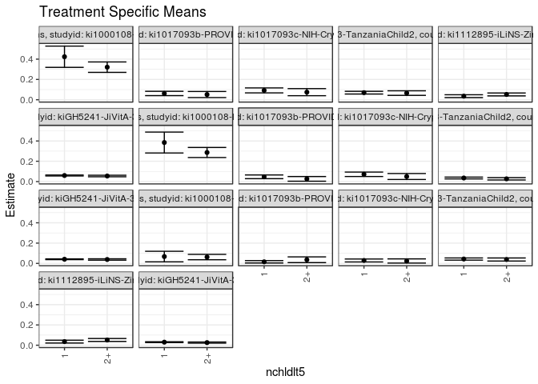

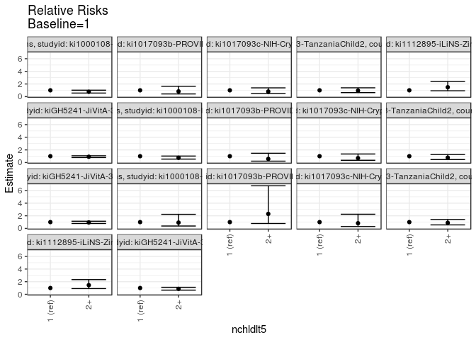

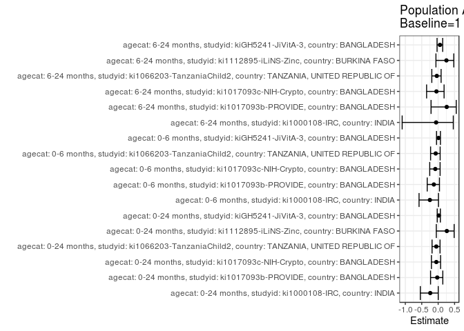

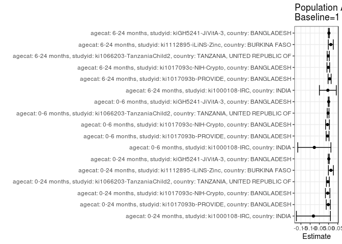

## Results Table

### Parameter: TSM

| agecat | studyid | country | intervention_level | baseline_level | estimate | ci_lower | ci_upper |
| --- | --- | --- | --- | --- | --- | --- | --- |
| 0-24 months | ki1000108-IRC | INDIA | 1 | NA | 0.4237602 | 0.3190542 | 0.5284663 |
| 0-24 months | ki1000108-IRC | INDIA | 2+ | NA | 0.3209920 | 0.2696459 | 0.3723381 |
| 0-24 months | ki1017093b-PROVIDE | BANGLADESH | 1 | NA | 0.0616871 | 0.0403876 | 0.0829865 |
| 0-24 months | ki1017093b-PROVIDE | BANGLADESH | 2+ | NA | 0.0511532 | 0.0212580 | 0.0810484 |
| 0-24 months | ki1017093c-NIH-Crypto | BANGLADESH | 1 | NA | 0.0920101 | 0.0675769 | 0.1164432 |
| 0-24 months | ki1017093c-NIH-Crypto | BANGLADESH | 2+ | NA | 0.0745439 | 0.0396552 | 0.1094325 |
| 0-24 months | ki1066203-TanzaniaChild2 | TANZANIA, UNITED REPUBLIC OF | 1 | NA | 0.0696284 | 0.0562594 | 0.0829975 |
| 0-24 months | ki1066203-TanzaniaChild2 | TANZANIA, UNITED REPUBLIC OF | 2+ | NA | 0.0655165 | 0.0430854 | 0.0879476 |
| 0-24 months | ki1112895-iLiNS-Zinc | BURKINA FASO | 1 | NA | 0.0350967 | 0.0209802 | 0.0492132 |
| 0-24 months | ki1112895-iLiNS-Zinc | BURKINA FASO | 2+ | NA | 0.0521705 | 0.0377890 | 0.0665521 |
| 0-24 months | kiGH5241-JiVitA-3 | BANGLADESH | 1 | NA | 0.0597554 | 0.0551614 | 0.0643494 |
| 0-24 months | kiGH5241-JiVitA-3 | BANGLADESH | 2+ | NA | 0.0547773 | 0.0470568 | 0.0624978 |
| 0-6 months | ki1000108-IRC | INDIA | 1 | NA | 0.3846708 | 0.2818037 | 0.4875379 |
| 0-6 months | ki1000108-IRC | INDIA | 2+ | NA | 0.2864252 | 0.2368119 | 0.3360385 |
| 0-6 months | ki1017093b-PROVIDE | BANGLADESH | 1 | NA | 0.0468750 | 0.0285532 | 0.0651968 |
| 0-6 months | ki1017093b-PROVIDE | BANGLADESH | 2+ | NA | 0.0265957 | 0.0035796 | 0.0496119 |
| 0-6 months | ki1017093c-NIH-Crypto | BANGLADESH | 1 | NA | 0.0717382 | 0.0499073 | 0.0935690 |
| 0-6 months | ki1017093c-NIH-Crypto | BANGLADESH | 2+ | NA | 0.0497305 | 0.0202995 | 0.0791615 |
| 0-6 months | ki1066203-TanzaniaChild2 | TANZANIA, UNITED REPUBLIC OF | 1 | NA | 0.0351669 | 0.0261483 | 0.0441854 |
| 0-6 months | ki1066203-TanzaniaChild2 | TANZANIA, UNITED REPUBLIC OF | 2+ | NA | 0.0270512 | 0.0155885 | 0.0385139 |
| 0-6 months | kiGH5241-JiVitA-3 | BANGLADESH | 1 | NA | 0.0408615 | 0.0369900 | 0.0447330 |
| 0-6 months | kiGH5241-JiVitA-3 | BANGLADESH | 2+ | NA | 0.0386436 | 0.0319025 | 0.0453847 |
| 6-24 months | ki1000108-IRC | INDIA | 1 | NA | 0.0674157 | 0.0152593 | 0.1195722 |
| 6-24 months | ki1000108-IRC | INDIA | 2+ | NA | 0.0623053 | 0.0358313 | 0.0887793 |
| 6-24 months | ki1017093b-PROVIDE | BANGLADESH | 1 | NA | 0.0156250 | 0.0041315 | 0.0271185 |
| 6-24 months | ki1017093b-PROVIDE | BANGLADESH | 2+ | NA | 0.0359281 | 0.0076783 | 0.0641779 |
| 6-24 months | ki1017093c-NIH-Crypto | BANGLADESH | 1 | NA | 0.0288462 | 0.0144505 | 0.0432418 |
| 6-24 months | ki1017093c-NIH-Crypto | BANGLADESH | 2+ | NA | 0.0238095 | 0.0031757 | 0.0444433 |
| 6-24 months | ki1066203-TanzaniaChild2 | TANZANIA, UNITED REPUBLIC OF | 1 | NA | 0.0430403 | 0.0322598 | 0.0538208 |
| 6-24 months | ki1066203-TanzaniaChild2 | TANZANIA, UNITED REPUBLIC OF | 2+ | NA | 0.0383428 | 0.0232980 | 0.0533876 |
| 6-24 months | ki1112895-iLiNS-Zinc | BURKINA FASO | 1 | NA | 0.0356728 | 0.0215940 | 0.0497515 |
| 6-24 months | ki1112895-iLiNS-Zinc | BURKINA FASO | 2+ | NA | 0.0517686 | 0.0373348 | 0.0662023 |
| 6-24 months | kiGH5241-JiVitA-3 | BANGLADESH | 1 | NA | 0.0301508 | 0.0260815 | 0.0342201 |
| 6-24 months | kiGH5241-JiVitA-3 | BANGLADESH | 2+ | NA | 0.0258777 | 0.0202687 | 0.0314867 |

### Parameter: E(Y)

| agecat | studyid | country | intervention_level | baseline_level | estimate | ci_lower | ci_upper |
| --- | --- | --- | --- | --- | --- | --- | --- |
| 0-24 months | ki1000108-IRC | INDIA | NA | NA | 0.3414634 | 0.2955068 | 0.3874201 |
| 0-24 months | ki1017093b-PROVIDE | BANGLADESH | NA | NA | 0.0600000 | 0.0423945 | 0.0776055 |
| 0-24 months | ki1017093c-NIH-Crypto | BANGLADESH | NA | NA | 0.0870712 | 0.0669870 | 0.1071555 |
| 0-24 months | ki1066203-TanzaniaChild2 | TANZANIA, UNITED REPUBLIC OF | NA | NA | 0.0658281 | 0.0558737 | 0.0757825 |
| 0-24 months | ki1112895-iLiNS-Zinc | BURKINA FASO | NA | NA | 0.0476638 | 0.0358801 | 0.0594476 |
| 0-24 months | kiGH5241-JiVitA-3 | BANGLADESH | NA | NA | 0.0609661 | 0.0574920 | 0.0644402 |
| 0-6 months | ki1000108-IRC | INDIA | NA | NA | 0.3073171 | 0.2626027 | 0.3520314 |
| 0-6 months | ki1017093b-PROVIDE | BANGLADESH | NA | NA | 0.0414286 | 0.0266555 | 0.0562017 |
| 0-6 months | ki1017093c-NIH-Crypto | BANGLADESH | NA | NA | 0.0659631 | 0.0482810 | 0.0836451 |
| 0-6 months | ki1066203-TanzaniaChild2 | TANZANIA, UNITED REPUBLIC OF | NA | NA | 0.0327044 | 0.0255647 | 0.0398441 |
| 0-6 months | kiGH5241-JiVitA-3 | BANGLADESH | NA | NA | 0.0413251 | 0.0383484 | 0.0443018 |
| 6-24 months | ki1000108-IRC | INDIA | NA | NA | 0.0634146 | 0.0397960 | 0.0870333 |
| 6-24 months | ki1017093b-PROVIDE | BANGLADESH | NA | NA | 0.0211382 | 0.0097604 | 0.0325160 |
| 6-24 months | ki1017093c-NIH-Crypto | BANGLADESH | NA | NA | 0.0273973 | 0.0155476 | 0.0392469 |
| 6-24 months | ki1066203-TanzaniaChild2 | TANZANIA, UNITED REPUBLIC OF | NA | NA | 0.0412935 | 0.0325931 | 0.0499940 |
| 6-24 months | ki1112895-iLiNS-Zinc | BURKINA FASO | NA | NA | 0.0476638 | 0.0358801 | 0.0594476 |
| 6-24 months | kiGH5241-JiVitA-3 | BANGLADESH | NA | NA | 0.0319334 | 0.0290403 | 0.0348265 |

### Parameter: RR

| agecat | studyid | country | intervention_level | baseline_level | estimate | ci_lower | ci_upper |
| --- | --- | --- | --- | --- | --- | --- | --- |
| 0-24 months | ki1000108-IRC | INDIA | 1 | 1 | 1.0000000 | 1.0000000 | 1.000000 |
| 0-24 months | ki1000108-IRC | INDIA | 2+ | 1 | 0.7574850 | 0.5642108 | 1.016967 |
| 0-24 months | ki1017093b-PROVIDE | BANGLADESH | 1 | 1 | 1.0000000 | 1.0000000 | 1.000000 |
| 0-24 months | ki1017093b-PROVIDE | BANGLADESH | 2+ | 1 | 0.8292373 | 0.4206917 | 1.634533 |
| 0-24 months | ki1017093c-NIH-Crypto | BANGLADESH | 1 | 1 | 1.0000000 | 1.0000000 | 1.000000 |
| 0-24 months | ki1017093c-NIH-Crypto | BANGLADESH | 2+ | 1 | 0.8101707 | 0.4732858 | 1.386850 |
| 0-24 months | ki1066203-TanzaniaChild2 | TANZANIA, UNITED REPUBLIC OF | 1 | 1 | 1.0000000 | 1.0000000 | 1.000000 |
| 0-24 months | ki1066203-TanzaniaChild2 | TANZANIA, UNITED REPUBLIC OF | 2+ | 1 | 0.9409442 | 0.6354257 | 1.393359 |
| 0-24 months | ki1112895-iLiNS-Zinc | BURKINA FASO | 1 | 1 | 1.0000000 | 1.0000000 | 1.000000 |
| 0-24 months | ki1112895-iLiNS-Zinc | BURKINA FASO | 2+ | 1 | 1.4864791 | 0.9216741 | 2.397399 |
| 0-24 months | kiGH5241-JiVitA-3 | BANGLADESH | 1 | 1 | 1.0000000 | 1.0000000 | 1.000000 |
| 0-24 months | kiGH5241-JiVitA-3 | BANGLADESH | 2+ | 1 | 0.9166929 | 0.7871623 | 1.067538 |
| 0-6 months | ki1000108-IRC | INDIA | 1 | 1 | 1.0000000 | 1.0000000 | 1.000000 |
| 0-6 months | ki1000108-IRC | INDIA | 2+ | 1 | 0.7445982 | 0.5413156 | 1.024220 |
| 0-6 months | ki1017093b-PROVIDE | BANGLADESH | 1 | 1 | 1.0000000 | 1.0000000 | 1.000000 |
| 0-6 months | ki1017093b-PROVIDE | BANGLADESH | 2+ | 1 | 0.5673759 | 0.2195194 | 1.466455 |
| 0-6 months | ki1017093c-NIH-Crypto | BANGLADESH | 1 | 1 | 1.0000000 | 1.0000000 | 1.000000 |
| 0-6 months | ki1017093c-NIH-Crypto | BANGLADESH | 2+ | 1 | 0.6932222 | 0.3562971 | 1.348753 |
| 0-6 months | ki1066203-TanzaniaChild2 | TANZANIA, UNITED REPUBLIC OF | 1 | 1 | 1.0000000 | 1.0000000 | 1.000000 |
| 0-6 months | ki1066203-TanzaniaChild2 | TANZANIA, UNITED REPUBLIC OF | 2+ | 1 | 0.7692241 | 0.4687702 | 1.262251 |
| 0-6 months | kiGH5241-JiVitA-3 | BANGLADESH | 1 | 1 | 1.0000000 | 1.0000000 | 1.000000 |
| 0-6 months | kiGH5241-JiVitA-3 | BANGLADESH | 2+ | 1 | 0.9457220 | 0.7848526 | 1.139564 |
| 6-24 months | ki1000108-IRC | INDIA | 1 | 1 | 1.0000000 | 1.0000000 | 1.000000 |
| 6-24 months | ki1000108-IRC | INDIA | 2+ | 1 | 0.9241952 | 0.3823225 | 2.234074 |
| 6-24 months | ki1017093b-PROVIDE | BANGLADESH | 1 | 1 | 1.0000000 | 1.0000000 | 1.000000 |
| 6-24 months | ki1017093b-PROVIDE | BANGLADESH | 2+ | 1 | 2.2994012 | 0.7834301 | 6.748842 |
| 6-24 months | ki1017093c-NIH-Crypto | BANGLADESH | 1 | 1 | 1.0000000 | 1.0000000 | 1.000000 |
| 6-24 months | ki1017093c-NIH-Crypto | BANGLADESH | 2+ | 1 | 0.8253968 | 0.3036345 | 2.243750 |
| 6-24 months | ki1066203-TanzaniaChild2 | TANZANIA, UNITED REPUBLIC OF | 1 | 1 | 1.0000000 | 1.0000000 | 1.000000 |
| 6-24 months | ki1066203-TanzaniaChild2 | TANZANIA, UNITED REPUBLIC OF | 2+ | 1 | 0.8908571 | 0.5590762 | 1.419532 |
| 6-24 months | ki1112895-iLiNS-Zinc | BURKINA FASO | 1 | 1 | 1.0000000 | 1.0000000 | 1.000000 |
| 6-24 months | ki1112895-iLiNS-Zinc | BURKINA FASO | 2+ | 1 | 1.4512068 | 0.9044227 | 2.328558 |
| 6-24 months | kiGH5241-JiVitA-3 | BANGLADESH | 1 | 1 | 1.0000000 | 1.0000000 | 1.000000 |
| 6-24 months | kiGH5241-JiVitA-3 | BANGLADESH | 2+ | 1 | 0.8582759 | 0.6634070 | 1.110386 |

### Parameter: PAR

| agecat | studyid | country | intervention_level | baseline_level | estimate | ci_lower | ci_upper |
| --- | --- | --- | --- | --- | --- | --- | --- |
| 0-24 months | ki1000108-IRC | INDIA | 1 | NA | -0.0822968 | -0.1745007 | 0.0099071 |
| 0-24 months | ki1017093b-PROVIDE | BANGLADESH | 1 | NA | -0.0016871 | -0.0128253 | 0.0094512 |
| 0-24 months | ki1017093c-NIH-Crypto | BANGLADESH | 1 | NA | -0.0049388 | -0.0170763 | 0.0071986 |
| 0-24 months | ki1066203-TanzaniaChild2 | TANZANIA, UNITED REPUBLIC OF | 1 | NA | -0.0038003 | -0.0118152 | 0.0042145 |
| 0-24 months | ki1112895-iLiNS-Zinc | BURKINA FASO | 1 | NA | 0.0125671 | -0.0009742 | 0.0261084 |
| 0-24 months | kiGH5241-JiVitA-3 | BANGLADESH | 1 | NA | 0.0012107 | -0.0016972 | 0.0041187 |
| 0-6 months | ki1000108-IRC | INDIA | 1 | NA | -0.0773538 | -0.1674002 | 0.0126927 |
| 0-6 months | ki1017093b-PROVIDE | BANGLADESH | 1 | NA | -0.0054464 | -0.0133754 | 0.0024825 |
| 0-6 months | ki1017093c-NIH-Crypto | BANGLADESH | 1 | NA | -0.0057751 | -0.0162512 | 0.0047010 |
| 0-6 months | ki1066203-TanzaniaChild2 | TANZANIA, UNITED REPUBLIC OF | 1 | NA | -0.0024625 | -0.0072277 | 0.0023028 |
| 0-6 months | kiGH5241-JiVitA-3 | BANGLADESH | 1 | NA | 0.0004636 | -0.0019791 | 0.0029063 |
| 6-24 months | ki1000108-IRC | INDIA | 1 | NA | -0.0040011 | -0.0497955 | 0.0417933 |
| 6-24 months | ki1017093b-PROVIDE | BANGLADESH | 1 | NA | 0.0055132 | -0.0027992 | 0.0138256 |
| 6-24 months | ki1017093c-NIH-Crypto | BANGLADESH | 1 | NA | -0.0014489 | -0.0086884 | 0.0057906 |
| 6-24 months | ki1066203-TanzaniaChild2 | TANZANIA, UNITED REPUBLIC OF | 1 | NA | -0.0017468 | -0.0075879 | 0.0040943 |
| 6-24 months | ki1112895-iLiNS-Zinc | BURKINA FASO | 1 | NA | 0.0119911 | -0.0015366 | 0.0255187 |
| 6-24 months | kiGH5241-JiVitA-3 | BANGLADESH | 1 | NA | 0.0017826 | -0.0009373 | 0.0045025 |

### Parameter: PAF

| agecat | studyid | country | intervention_level | baseline_level | estimate | ci_lower | ci_upper |
| --- | --- | --- | --- | --- | --- | --- | --- |
| 0-24 months | ki1000108-IRC | INDIA | 1 | NA | -0.2410121 | -0.5434233 | 0.0021460 |
| 0-24 months | ki1017093b-PROVIDE | BANGLADESH | 1 | NA | -0.0281179 | -0.2312950 | 0.1415328 |
| 0-24 months | ki1017093c-NIH-Crypto | BANGLADESH | 1 | NA | -0.0567216 | -0.2050123 | 0.0733202 |
| 0-24 months | ki1066203-TanzaniaChild2 | TANZANIA, UNITED REPUBLIC OF | 1 | NA | -0.0577313 | -0.1861739 | 0.0568032 |
| 0-24 months | ki1112895-iLiNS-Zinc | BURKINA FASO | 1 | NA | 0.2636618 | -0.0565620 | 0.4868319 |
| 0-24 months | kiGH5241-JiVitA-3 | BANGLADESH | 1 | NA | 0.0198594 | -0.0290669 | 0.0664595 |
| 0-6 months | ki1000108-IRC | INDIA | 1 | NA | -0.2517067 | -0.5820184 | 0.0096388 |
| 0-6 months | ki1017093b-PROVIDE | BANGLADESH | 1 | NA | -0.1314655 | -0.3337876 | 0.0401663 |
| 0-6 months | ki1017093c-NIH-Crypto | BANGLADESH | 1 | NA | -0.0875504 | -0.2565761 | 0.0587391 |
| 0-6 months | ki1066203-TanzaniaChild2 | TANZANIA, UNITED REPUBLIC OF | 1 | NA | -0.0752945 | -0.2302760 | 0.0601634 |
| 0-6 months | kiGH5241-JiVitA-3 | BANGLADESH | 1 | NA | 0.0112184 | -0.0497099 | 0.0686102 |
| 6-24 months | ki1000108-IRC | INDIA | 1 | NA | -0.0630942 | -1.0962703 | 0.4608666 |
| 6-24 months | ki1017093b-PROVIDE | BANGLADESH | 1 | NA | 0.2608173 | -0.2163881 | 0.5508086 |
| 6-24 months | ki1017093c-NIH-Crypto | BANGLADESH | 1 | NA | -0.0528846 | -0.3520426 | 0.1800806 |
| 6-24 months | ki1066203-TanzaniaChild2 | TANZANIA, UNITED REPUBLIC OF | 1 | NA | -0.0423020 | -0.1934800 | 0.0897264 |
| 6-24 months | ki1112895-iLiNS-Zinc | BURKINA FASO | 1 | NA | 0.2515760 | -0.0677512 | 0.4754036 |
| 6-24 months | kiGH5241-JiVitA-3 | BANGLADESH | 1 | NA | 0.0558217 | -0.0337534 | 0.1376351 |